# Fundamentos de Estatística

NOV/2015

## Sobre o Curso

Instrutor: Lucas Mation, IPEA, Economista Contato: lucasmation@gmail.com

Os materiais (dados) do curso estão disponíveis em: https://github.com/lucasmation/Curso_Fundamentos_da_Estatistica

Slides serão disponibilizados após as aulas

## O que é ESTATISTICA?

Conjunto de técnicas para trabalhar com dados. Duas grandes áraeas:

### Estatística Descritiva

### Análise

## O que é ESTATISTICA?

### Estatística Descritiva

- Coleta
  - Amostragem, Operacionalização
- Organização/Manipulação
  - Softwares Estatísticos , Progamação
- Apresentação
  - Graficos, tabelas com estatísticas descritivas

## O que é ESTATISTICA?

### Análise

- Inferência
  - Estmimar características/parâmetros desconhecidos da população a partir de de dados amostrais
  - Previsão
  - Teste de Hopóteses
- Busca de causalidade
  - corr \(\neq\) causalidade!
  - Regressão: métodos que permitem controlar para variáveis observáveis
  - Experimentos Naturais

## O que é ESTATISTICA?

Diagrama fundamental da Estatística

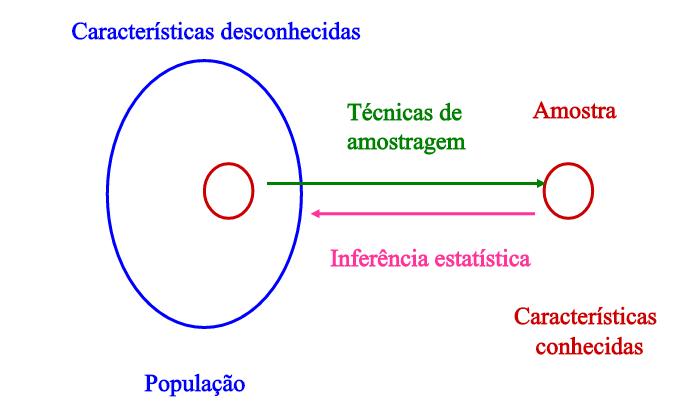

## O que é ESTATISTICA?

Fundamento empírico de diversas áreas.

- Medicina
- Socilologia
- Economia
- Epidemeologia
- Ciência Política
- Psicologia

~ Quanto menos "experimetal/laboratorial" é a ciência, maior é o uso da estatística

## O que é ESTATISTICA?

Diga as áreas da Estatística usadas nas seguintes aplicações?

- Calculo do salário médio no Brasil
  - Suponha dados censitários
  - Agora suponha dados amostrais. O que muda?
  - Há diferença salarial entre homens e mulheres?
  - Isso se deve a discriminação ou outros fatores?
- Previsão do tempo
- Efeito da corrupção no crescimento econômico

## Definições

- População: conjunto de todos os elementos de interesse
- Amostra: subconjunto de elementos da população
- Variável: atributo que descreve um elemento/indivíduo da população, podendo variar entre indivíduos
- Parâmetro: característica mensurável da pupulação (média, desvio padrão)
- Estatística: característica mensuráve da amostra

## Notação

- \(\sum_{i=1}^{n} X_i\) : Somatório de \(X_1\) a \(X_n\)
- \(\mu\) : Média populacional
- \(\bar{x}\) : Média amostral
- \(\sigma^2\), var(X) : Variância
- \(\sigma\), std(X) , dp(X) : Desvio Padrão

## Notação

- \(p\left({x}\right)\), \(p_X\left({x}\right)\): probabilidade do evento \(x\) ocorrer
- \(p\left({a \mid b}\right)\) : prob. de a dado b
- \(p\left({a \cup b}\right)\) : prob. de a OU b
- \(p\left({a \cap b}\right)\) : prob. de a E b

## Tipos de Variável

Numéricas (quantitativas):

- Contínuas
- Inteiras

Categórica (qualitativa)

- Nomanial
  - Binária (Dicotomica)
- Ordinal

## Tipos de Variável

Vamos usar a base de dados ex1_dados_pessoas.csv

```r
d <- read.csv2('data/ex1_dados_pessoas.csv')
d
```

```
##       Nome Sexo idade altura N_filhos    Time_Fut Class_Brasileirao
## 1     Joao    M    65   1.75        3       Goiás                17
## 2  Cláudia    F    31   1.72        1 Ponte Preta                 9
## 3    Maria    F    12   1.68        0   São Paulo                 5
## 4    Pedro    M    40   1.80        3       Vasco                19
## 5   Fulana    F    45   1.64        2  Portuguesa                NA
## 6 Beltrana    F    20   1.68        0   Palmeiras                 9
```

## Tipos de Variável

[output not shown]

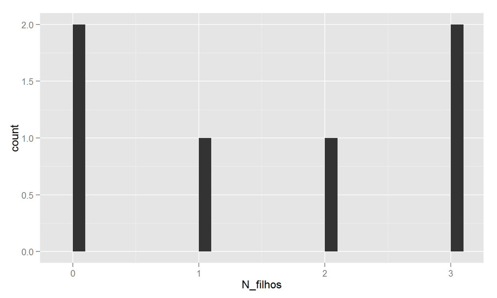

Classifique os tipos de variável da tabela acima

Note a classificação no Brasileirão do time de futebol de Fulana. O que ocorre? Por que?

## Dados e o computador

Investige as "entranhas"" do arquivo ex1_dados_pessoas.csv "internamente". (clicar com botão direito > abrir com > notepad ou wordpad)

qual o separador do arquivo? porque não vírgula?

## Minha 1a PNAD

Vamos olhar os microdados da PNAD

Visite: http://www.ibge.gov.br/ > populacao (sem clicar) > PNAD > microdados

Abra os microdados

Abra os dicionários importadores

Qual é a lógica?

## Minha 1a PNAD

Para facilitar o manuseio, já preparei o script de improtação dos dados. Veja no arquivo: importa_dados_PNAD_2013.R

```r
#Importando o arquivo no R:
load('data/pnad2013_pes_mastigada.Rda')
# importando do CSV:
# pnad2013_pes <- read.csv2('data/pnad2013_pes_mastigada.Rda')
summary(pnad2013_pes)
```

```
##  sexo           idade                    raca        horas_trabalhadas
##  M:145343   Min.   : 10.00   Indígena      :  1289   Min.   : NA
##  F:158060   1st Qu.: 22.00   Branca        :129184   1st Qu.: NA
##             Median : 35.00   Preta         : 26803   Median : NA
##             Mean   : 37.67   Amarela       :  1281   Mean   :NaN
##             3rd Qu.: 51.00   Parda         :144846   3rd Qu.: NA
##             Max.   :109.00   Sem declaração:     0   Max.   : NA
##                                                      NA's   :303403
##  anos_de_estudo    renda_total        peso_pes
##  Min.   : 1.000   Min.   :     0   Min.   : 174.0
##  1st Qu.: 5.000   1st Qu.:     0   1st Qu.: 320.0
##  Median : 9.000   Median :   678   Median : 570.0
##  Mean   : 8.609   Mean   :  1078   Mean   : 556.8
##  3rd Qu.:12.000   3rd Qu.:  1200   3rd Qu.: 726.0
##  Max.   :17.000   Max.   :180000   Max.   :1150.0
##
```

## Tabelas de Fequência

Contam o número de observações de:

- categorias (categóricas) ou numéricas discretas
- intervalos de números inteiros (ex: 0-9, 10-19, etc)

### Exercício:

A partir dos dados em **ex1_dados_pessoas.csv**, crie a tabela de frequências da variável sexo.

- Primeiro faça "manualmente"

## Tabelas de Fequência

### Exercício: tabela de frequências

A partir dos dados em **ex1_dados_pessoas.csv**, crie a da variável sexo.

- Tente replicar esta tabela usando o software (Excel Ou R) .Dicas:
  - No Excel: Você pode usar a função **=CONT.SE()** . Ou também uma Tabela Dinâmica
  - No R selecione a variável sexo com *pnad2013_pes$sexo*. Use a função *table()*
- Tente adicionar a "frequencia relativa" (quantos % da amostra cada categoria representa)
- Faça um gráfico de barras do resultado desta tabela

## Tabelas de Fequência

Solução No Excel:

- =count.se()

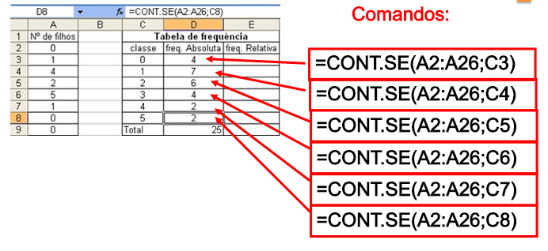

## Tabelas de Fequência

Solução No R:

```r
d <- read.csv2('data/ex1_dados_pessoas.csv')
table(d$Sexo)
```

```
##
## F M
## 4 2
```

```r
#melhorando a formatação
as.data.frame(table(d$Sexo))
```

```
##   Var1 Freq
## 1    F    4
## 2    M    2
```

## Tabelas de Fequência

Solução No R:

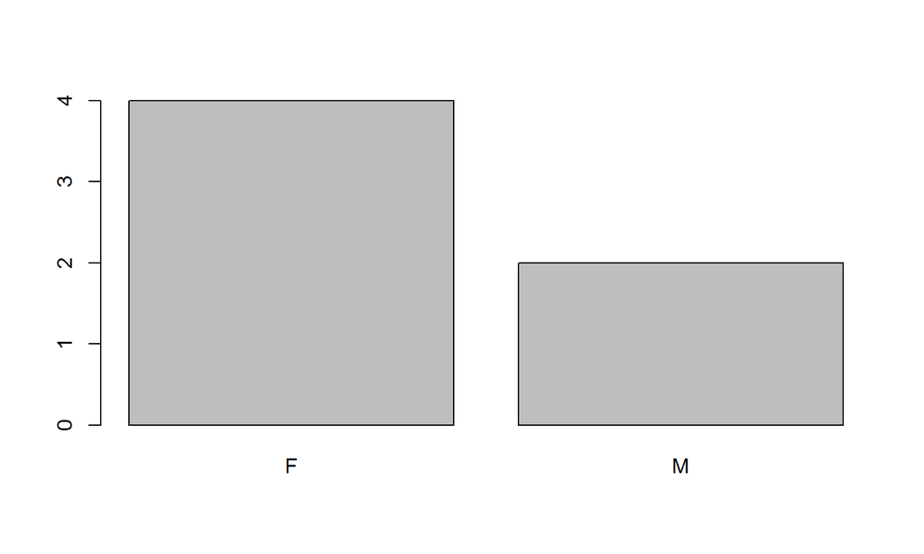

```r
barplot(table(d$Sexo))
```

## Tabelas de Fequência

Solução no Excel:

- uma saida seria replicar o que foi feito anteriormente (=cont.se())
- Outra possibilidade é uma tabela dinamica (demonstrar em aula)

## Tabelas de Fequência

Solução No R:

```r
d <- read.csv2('data/pnad2013_pes_mastigada.csv')
as.data.frame(table(d$sexo))
```

```
##   Var1   Freq
## 1    F 158060
## 2    M 145343
```

## Histograma

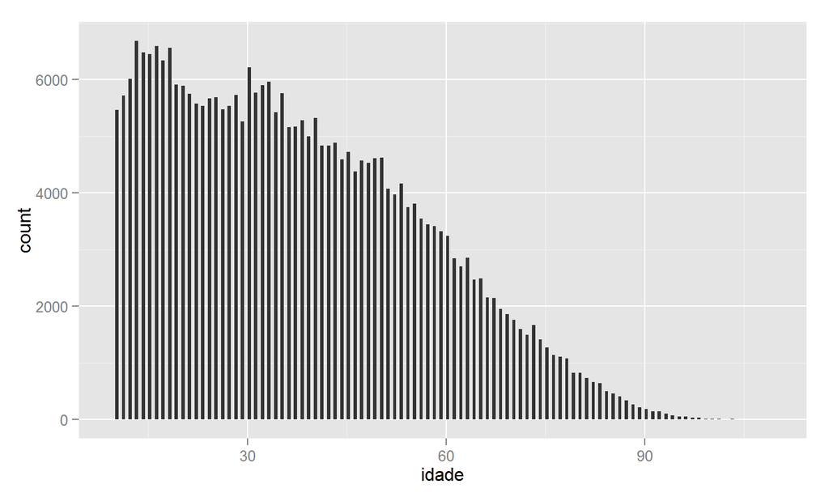

```r
ggplot(pnad2013_pes, aes(idade)) + geom_histogram(binwidth = .5)
```

## Histograma

Mudando a largura do intervalo (binwidth)

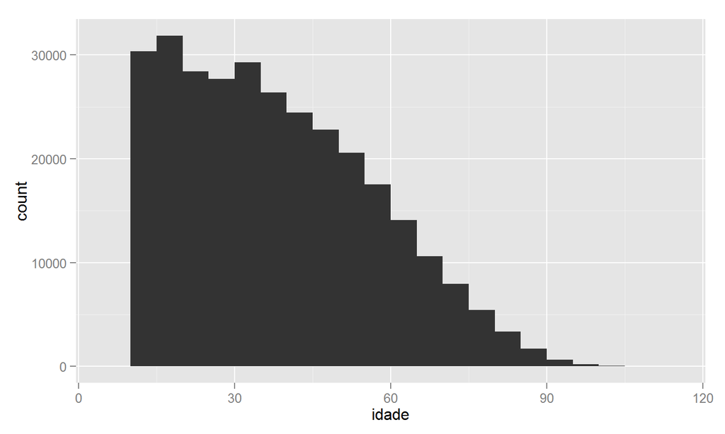

```r
ggplot(pnad2013_pes, aes(idade)) + geom_histogram(binwidth = 5)
```

## Histograma

Mudando a largura do intervalo (binwidth)

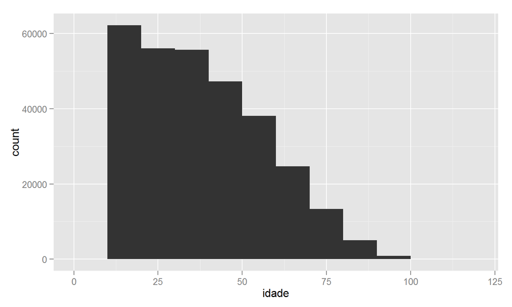

```r
ggplot(pnad2013_pes, aes(idade)) + geom_histogram(binwidth = 10)
```

## Histograma

Mudando a largura do intervalo (binwidth)

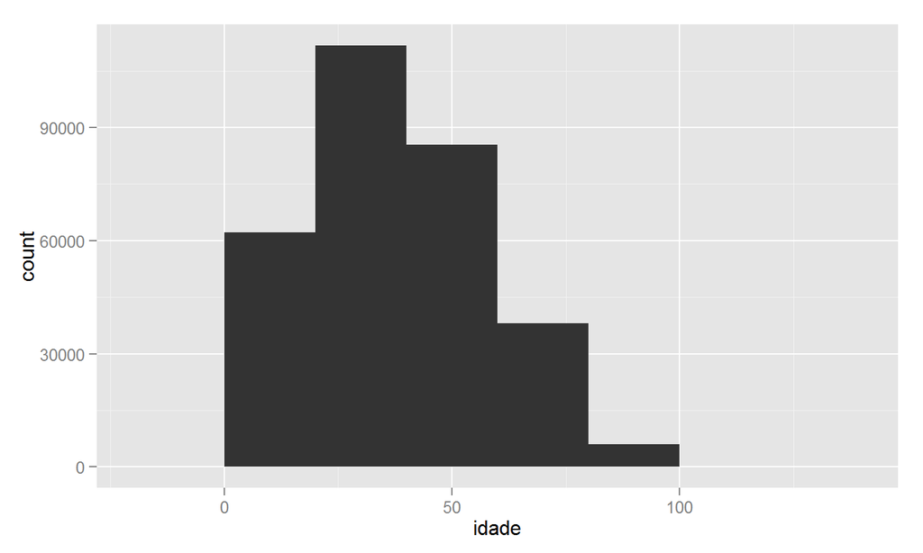

```r
ggplot(pnad2013_pes, aes(idade)) + geom_histogram(binwidth = 20)
```

## Grafico de pontos (scatter plot)

```r
library(dplyr)
```

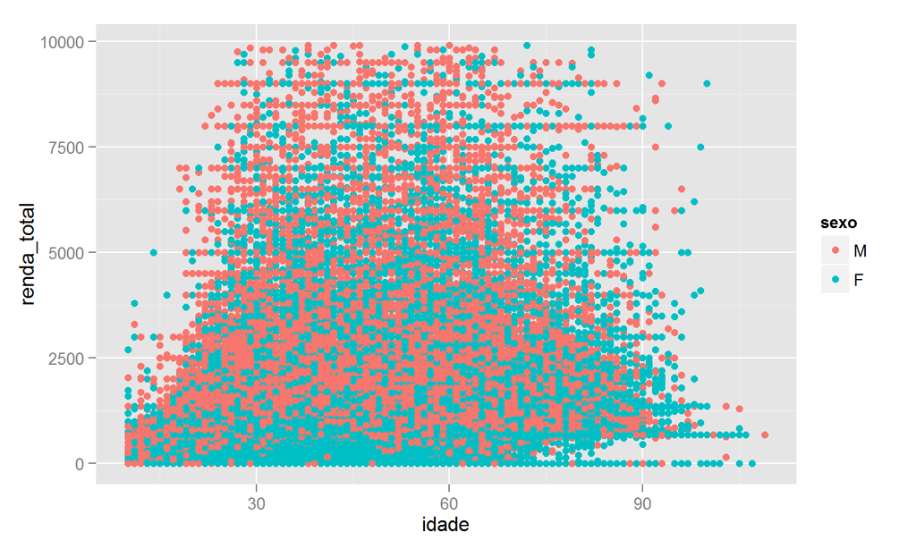

```r
pnad2013_pes %>% filter(renda_total<10000) %>% ggplot(aes(y=renda_total,x=idade,, colour = sexo)) + geom_point()
```

## Grafico de pontos (scatter plot)

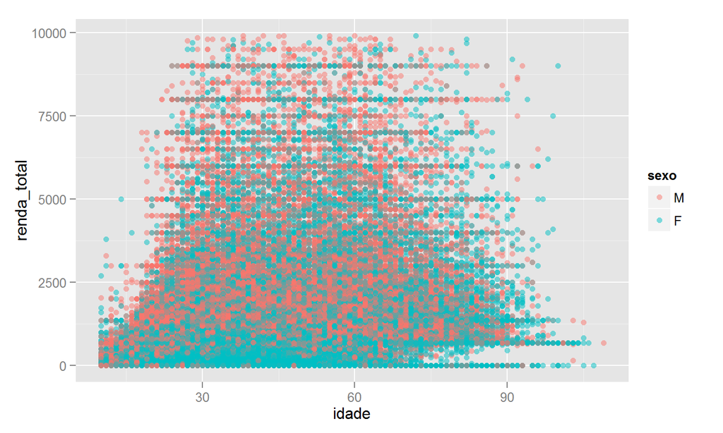

```r
pnad2013_pes %>% filter(renda_total<10000) %>% ggplot(aes(y=renda_total,x=idade,, colour = sexo)) + geom_point(alpha=0.5)
```

## Graficos e Tabelas: Formatação

Dicas de fomtação:

Gráfico de pizza? Não usar! [Veja aqui porque](http://darkhorseanalytics.com/blog/wp-content/uploads/2014/09/devourThePie3.gif)

Tabelas: preferencialmente sem cores e linhas internas, etc. [Bom exempolo aqui](http://urbandemographics.blogspot.co.uk/2014/08/how-to-make-your-tables-less-terrible.html)

## Medidas de Tendência Central

### Média

Populacional

\[\mu = \frac{\sum_{i=1}^{N} X_i} {N}\]

Amostral

\[\bar{x} = \frac{\sum_{i=1}^{ {N}} X_i} {N}\]

## Medidas de Tendência Central

### Mediana

Valor do meio de uma lista ordenada de números.

### MOda:

Valor mais comum de uma lista de números.

## Medidas de Tendência Central

Em um país com renda extremamente desigual, o que é maior, a média ou a mediana?

Encontre a moda dos salários no Brasil

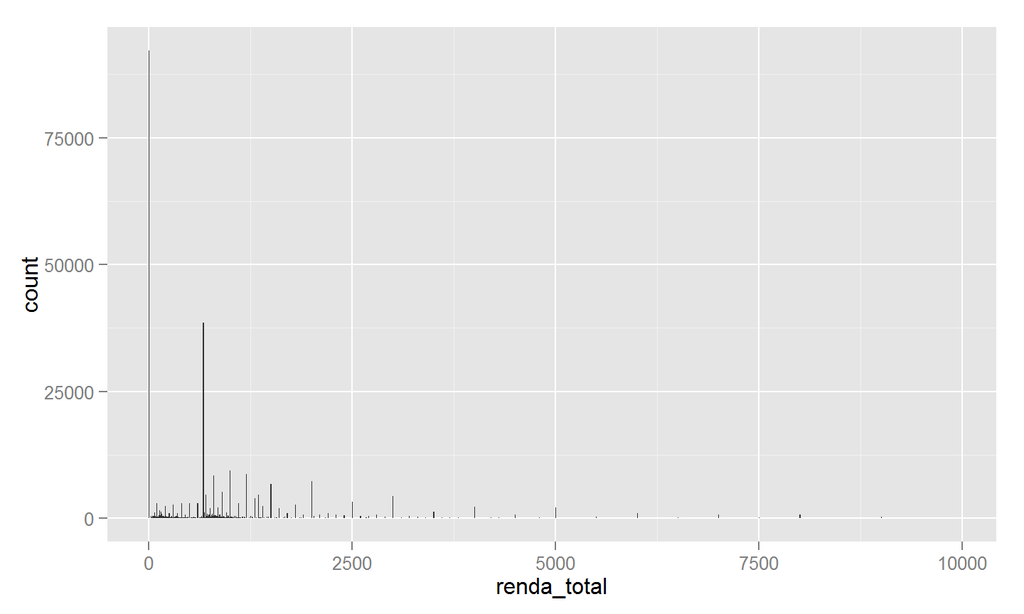

```r
library(dplyr)
pnad2013_pes %>% filter(renda_total<10000) %>% ggplot(aes(renda_total)) + geom_histogram(binwidth =10)
```

## Summary

```r
summary(pnad2013_pes)
```

```
##  sexo           idade                    raca        horas_trabalhadas
##  M:145343   Min.   : 10.00   Indígena      :  1289   Min.   : NA
##  F:158060   1st Qu.: 22.00   Branca        :129184   1st Qu.: NA
##             Median : 35.00   Preta         : 26803   Median : NA
##             Mean   : 37.67   Amarela       :  1281   Mean   :NaN
##             3rd Qu.: 51.00   Parda         :144846   3rd Qu.: NA
##             Max.   :109.00   Sem declaração:     0   Max.   : NA
##                                                      NA's   :303403
##  anos_de_estudo    renda_total        peso_pes
##  Min.   : 1.000   Min.   :     0   Min.   : 174.0
##  1st Qu.: 5.000   1st Qu.:     0   1st Qu.: 320.0
##  Median : 9.000   Median :   678   Median : 570.0
##  Mean   : 8.609   Mean   :  1078   Mean   : 556.8
##  3rd Qu.:12.000   3rd Qu.:  1200   3rd Qu.: 726.0
##  Max.   :17.000   Max.   :180000   Max.   :1150.0
##
```

## Medidas de Dispersão

### Variância

Populacional: \[\sigma^2 = \frac{\sum_{i=1}^{N}(x_i - \mu)^2} {N}\]

Amostral: \[\S^2 = \frac{\sum_{i=1}^{\widetilde{N}}(x_i - \bar{x})^2} {\widetilde{N}-1}\]

## Medidas de Dispersão

### Desvios Padrão

Raiz quadrada da variância: \(\sigma = \sqrt{\sigma^2}\) , \(\S = \sqrt{\S^2}\), respectivamente. Retoma a dimensionalidade da variável original.

### Coeficiente de variação

\[cv=\frac{S} {\bar{x}} *100\]

## Medidas de Dispersão

## Graficos e Tabelas: Formatação

Dicas de fomatação:

Gráfico de pizza? Não usar! [Veja aqui porque](http://darkhorseanalytics.com/blog/wp-content/uploads/2014/09/devourThePie3.gif)

Tabelas: preferencialmente sem cores e linhas internas, etc. [Bom exempolo aqui](http://urbandemographics.blogspot.co.uk/2014/08/how-to-make-your-tables-less-terrible.html)

## Distribuição

Distribuição dos valores de x

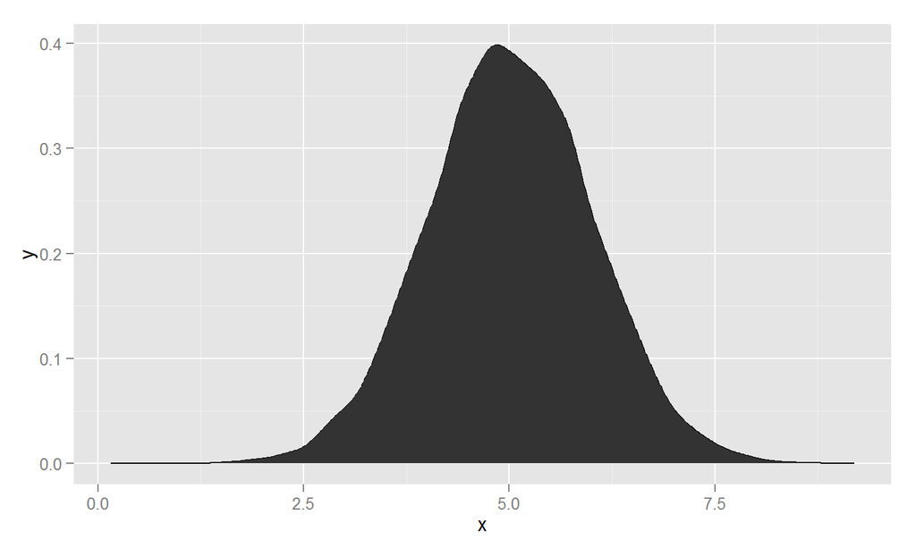

## Percentis

Definição: Valor da variável abaixo do qual está certo percentual das observações.

Percentis de interesse:

- 25%, 50% e 75%: tambem chamados de "quartis" pois dividem as observações quatro grupos
- 1% e 99% (ou 5% e 95%): permitem identificar valores aberrantes, discrepantes

## Percentis

O percentil 25%, também conhecido como 1o quartil

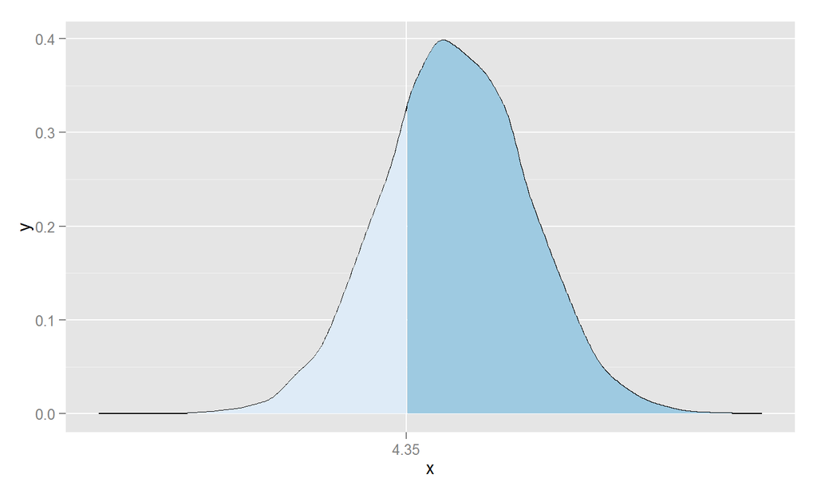

## Percentis

O percentil 50%, também conhecido como *mediana*

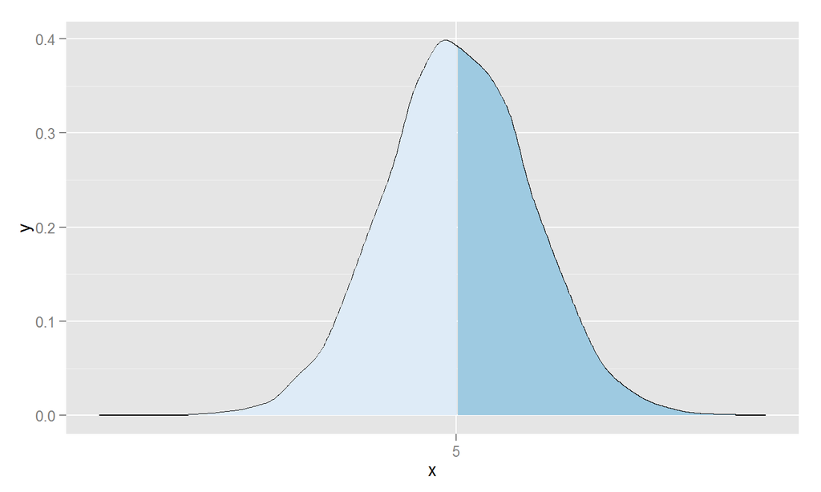

## Percentis

O percentil 75%, também conhecido como 3o quartil

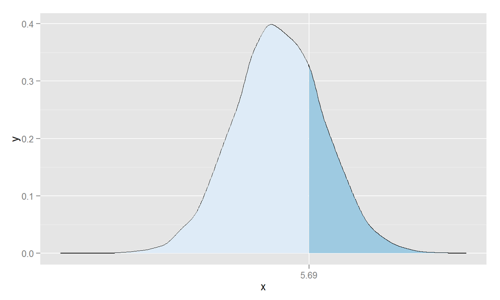

## Percentis

"Amplitude inter quartil": intervalo entre o 1o e o 3o quartis

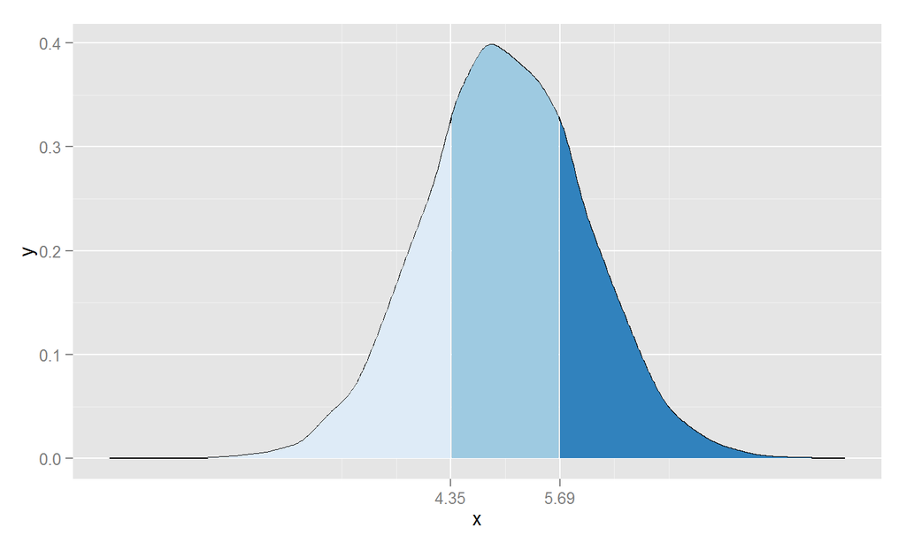

## Percentis

Outliers: percentis 1% e 99%

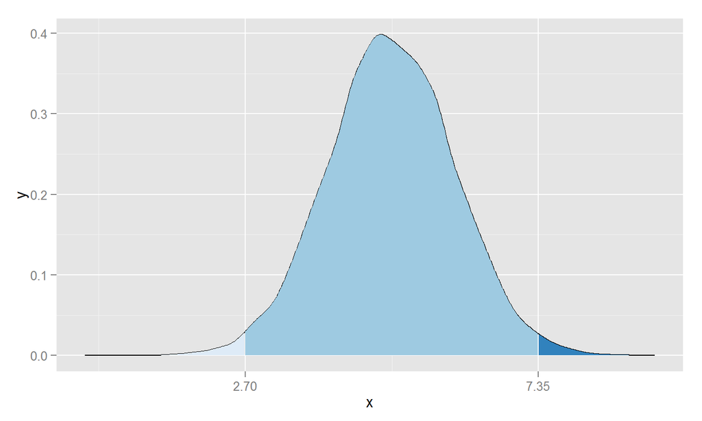

## Percentis

Outliers: percentis 1% e 99%

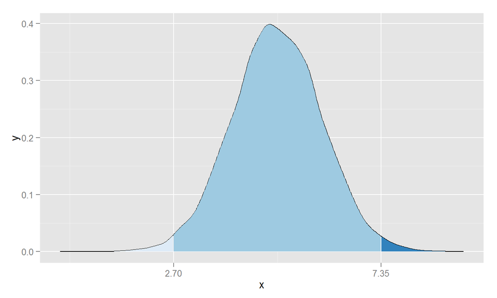

### Percentis

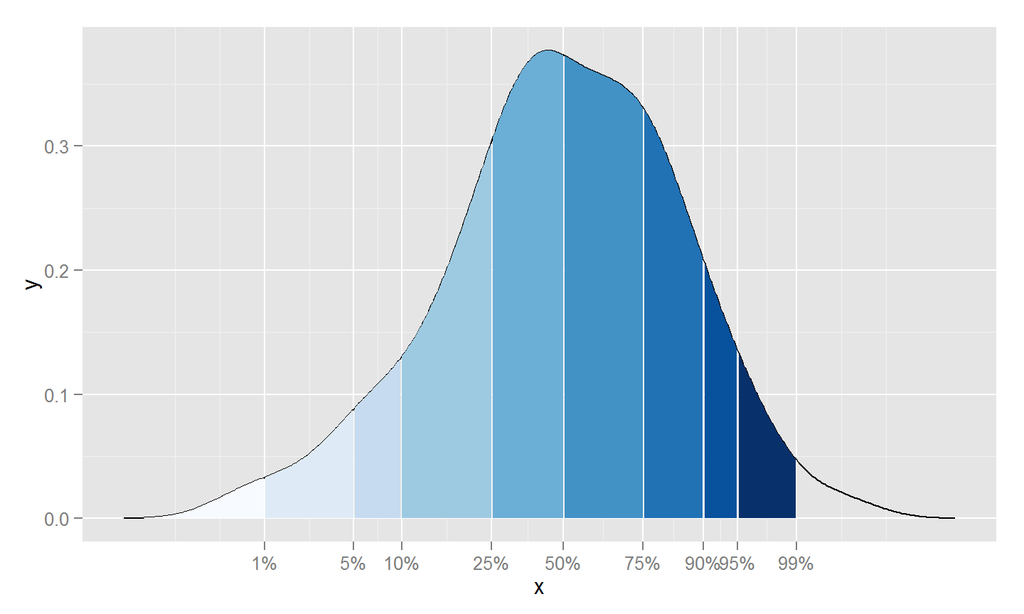

## Medidas de Dispersão

### Amplitude

Diferença entre o menor e maior valor da variável.

### Amplitude inter-quartil

Diferença entre o o 1o e 3o quartis. Após ordenar a variável, computar o percentil

## Amostragem

Tipos de Amostras:

- Probabilistica/Aleatória
  - Simples
    - Sistemática
  - Conglomerada
  - Esrtatificada
- Não Probabilístia
  - Por Cotas
  - Por Conveniencia(voluntária)

## Amostragem

Vamos discutir os tipos de amostras nestes 3 tipos de pesquisa:

PNAD CENSO Demográfico (questionário detalhado) Pesquisas Eleitorais

## Notação

- N: tamanho da população
- n: tamanho da amostra
- \(f=\frac{n} {N}\) : fração amostral

Como determinar *n* ?

\[n=(\frac{z'*\sigma} {MDE})^2\]

Onde:

- z' : limintes dos intervalos de confiança
- \(\sigma\) : desvio padrão populacional. Estimado pelo desvio padrão encontrado no pré-teste, ou pesquisas anteriores
- MDE: margen de erro